# EDAV Project: UFO Sightings

Josh Feldman (jbf2159), Ramy Jaber (rij2105), Davis DeRodes (rd2804), Zach Bogart (zb2223)

4/5/2018

# 4 Main Analysis

## Cleaning

*Provide a detailed, well-organized description of data quality, including textual description, graphs, and code.*

This file takes the raw dataset and standardizes the output so EDA is easier.

**Note: This file takes a while to run**

We separated it from the rest of the analysis to make it easier to work with the files and since knitting the document would either take a while or cache a lot.

Let’s get cleaning! The dataset was scraped from the [National UFO Reporting Center](http://www.nuforc.org/). Initially, the data was quite disorganized. Here is a look at the raw data. Before reading in the data, we considered `unknown` to be considered as an `NA` value. There were two observations (row number 3974, 74439) that did not work with our data cleaning process due to it’s strange formatting.

```r
# read in raw data
ufo <- as_tibble(read_csv("data/ufo_data_final.csv", na=c('unknown', '', 'Unknown')))
#Bad Eggs
ufo <- ufo[-c(3974, 74439),]
print(head(ufo, n=5))
```

```
## # A tibble: 5 x 11
##      X1 `Date / Time`                 City State    Shape   Duration
##   <int>         <chr>                <chr> <chr>    <chr>      <chr>
## 1     0 6/30/00 00:00  Myers Spring Canyon    TX   Circle       <NA>
## 2     0 3/29/17 05:30              Madison    CT   Circle 10 minutes
## 3     0 2/15/14 23:30 St. Norbert (Canada)    MB    Light  5 minutes
## 4     0 4/14/61 08:00   Nurnburg (Germany)  <NA> Cylinder    30 nins
## 5     0       7/18/15     London (England)  <NA>     <NA> 10 minutes
## # ... with 5 more variables: Summary <chr>, Posted <chr>, year <int>,
## #   month <chr>, Desc <chr>
```

An easy fix is to correct the date formats. We converted the `Posted` column to a standard date format.

```r
#Posted
ufo$Posted <- as.Date(ufo$Posted, format = "%m/%d/%y")
```

And we converted the `Date / Time` into separate columns for easier access:

```r
#Add Date and Time
getDateFromDateTime <- function(dateTimeString, year){
  date <- strsplit(dateTimeString, " ")[[1]][1]
  elements <- strsplit(date, "/")[[1]]
  dateFinal <- paste(c(elements[1], elements[2], year), collapse="/")
  return(dateFinal)
}

getTimeFromDateTime <- function(dateTimeString){
  # return(dateTimeString)
  time <- strsplit(dateTimeString, " ")[[1]][2]
  return(time)
}

ufo <- ufo %>%
  rowwise() %>%
  mutate(
    Date = as.Date(getDateFromDateTime(`Date / Time`, `year`), format = "%m/%d/%Y"),
    Time = getTimeFromDateTime(`Date / Time`)
  )

print(head(ufo, n=5))
```

```
## # A tibble: 5 x 13
##      X1 `Date / Time`                 City State    Shape   Duration
##   <int>         <chr>                <chr> <chr>    <chr>      <chr>
## 1     0 6/30/00 00:00  Myers Spring Canyon    TX   Circle       <NA>
## 2     0 3/29/17 05:30              Madison    CT   Circle 10 minutes
## 3     0 2/15/14 23:30 St. Norbert (Canada)    MB    Light  5 minutes
## 4     0 4/14/61 08:00   Nurnburg (Germany)  <NA> Cylinder    30 nins
## 5     0       7/18/15     London (England)  <NA>     <NA> 10 minutes
## # ... with 7 more variables: Summary <chr>, Posted <date>, year <int>,
## #   month <chr>, Desc <chr>, Date <date>, Time <chr>
```

The `Shape` column had a lot of different results. As a quick pass, we merged some results that were just different tenses of the same word:

```r
print("Before")
```

```
## [1] "Before"
```

```r
print(table(ufo$Shape))
```

```
##
##    changed   changing   Changing    Chevron      cigar      Cigar
##          1          1       2779       1334          3       2744
##     circle     Circle       Cone   Crescent      Cross   cylinder
##          8      11825        480          2        351          5
##   Cylinder      delta      Delta    diamond    Diamond       Disk
##       1764          1          7          2       1705       7108
##       Dome        egg        Egg   fireball   Fireball      Flare
##          1          1       1022          2       8796          1
##      flash      Flash  Formation    Hexagon      light      Light
##          1       2050       3571          1         58      23285
##      other      Other       oval       Oval    pyramid  rectangle
##         18       7906          2       5147          1          4
##  Rectangle      Round     sphere     Sphere   Teardrop   triangle
##       1900          2          7       7566       1041         18
##   Triangle TRIANGULAR
##      10701          1
```

```r
#Clean Shape
ufo$Shape <- tolower(ufo$Shape)
ufo$Shape[ufo$Shape == "triangular"] <- "triangle"
ufo$Shape[ufo$Shape == "changed"] <- "changing"

print("After")
```

```
## [1] "After"
```

```r
print(table(ufo$Shape))
```

```
##
##  changing   chevron     cigar    circle      cone  crescent     cross
##      2781      1334      2747     11833       480         2       351
##  cylinder     delta   diamond      disk      dome       egg  fireball
##      1769         8      1707      7108         1      1023      8798
##     flare     flash formation   hexagon     light     other      oval
##         1      2051      3571         1     23343      7924      5149
##   pyramid rectangle     round    sphere  teardrop  triangle
##         1      1904         2      7573      1041     10720
```

Next, the `State` column contained many states that were actually not US States such as Ontario, Canada. Notice how the number of states is much larger than 50:

```r
print(table(ufo$State))
```

```
##
##    AB    AK    AL    AR    AZ    BC    Ca    CA    CO    CT    DC    DE
##   513   538  1050   910  3903  1015     1 13188  2397  1419   133   306
##    Fl    FL    GA    HI    IA    ID    IL    IN    KS    KY    LA    MA
##     4  6250  2049   513   966   906  3489  1888   925  1280   903  2025
##    MB    MD    ME    MI    MN    MO    MS    MT    NB    NC    ND    NE
##   217  1432   908  2906  1609  2197   609   784   168  2824   201   544
##    NF    NH    NJ    NM    NS    NT    NV    NY    OH    OK    ON    OR
##    39   856  2178  1253   195    24  1317  4552  3439  1110  2055  2734
##    PA    PE    PQ    PR    QC    RI    SA    SC    SD    SK    TN    TX
##  3761    24   102    37   244   467    39  1718   300   145  1752  4830
##    UT    VA    VI    VT    WA    WI    WV    WY    YK    YT
##  1093  2046     1   461  5715  1919   704   310     6    20
```

```r
print(sprintf("Number of States: %d", dim(table(ufo$State))))
```

```
## [1] "Number of States: 70"
```

```r
clean_state <- function(state){
  if (is.na(state)) {
    return(NA)
  }
  if(state == "Ca"){
    return("CA")
  }
  if(state == "Fl"){
    return("FL")
  }
  return(state)
}

ufo$State = lapply(ufo$State, clean_state)
ufo$State = unlist(ufo$State)
```

To differentiate USA from non-USA states, we added a column to signify if the sighting occurred in one of the fifty US states or not.

```r
#Add In USA Column
in_usa <- function(value) {
  states <- c("AL", "AK", "AZ", "AR", "CA", "CO", "CT", "DC", "DE", "FL", "GA",
              "HI", "ID", "IL", "IN", "IA", "KS", "KY", "LA", "ME", "MD",
              "MA", "MI", "MN", "MS", "MO", "MT", "NE", "NV", "NH", "NJ",
              "NM", "NY", "NC", "ND", "OH", "OK", "OR", "PA", "RI", "SC",
              "SD", "TN", "TX", "UT", "VT", "VA", "WA", "WV", "WI", "WY")
  if (value %in% states) {
    return(TRUE)
  }
  else {
    return(FALSE)
  }
}

ufo <- ufo %>%
  mutate(
      In_USA = in_usa(`State`)
    )

print(head(ufo, n=5))
```

```
## # A tibble: 5 x 14
##      X1 `Date / Time`                 City State    Shape   Duration
##   <int>         <chr>                <chr> <chr>    <chr>      <chr>
## 1     0 6/30/00 00:00  Myers Spring Canyon    TX   circle       <NA>
## 2     0 3/29/17 05:30              Madison    CT   circle 10 minutes
## 3     0 2/15/14 23:30 St. Norbert (Canada)    MB    light  5 minutes
## 4     0 4/14/61 08:00   Nurnburg (Germany)  <NA> cylinder    30 nins
## 5     0       7/18/15     London (England)  <NA>     <NA> 10 minutes
## # ... with 8 more variables: Summary <chr>, Posted <date>, year <int>,
## #   month <chr>, Desc <chr>, Date <date>, Time <chr>, In_USA <lgl>
```

Next was extracting the country from the `City` column. Many of the rows had the country in the `City` column in parentheses, usually if it was international. To do this, we wrote a function that grabbed the value inside the parentheses and checked if it was a valid country. After this, we had access to different countries and cities where the sightings occurred. **Note: This is the part that takes a while to run :)**

```r
world <- map("world", plot=FALSE)

extract_country <- function(city){

if(is.na(city)){
  return(NA)
}

else if(grepl( '\\)', city) == TRUE){
  words <- unlist(strsplit(city, "\\("))
  potential_country <- substr(words[2], 1, nchar(words[2])-1)
  if(potential_country %in% world$names)
    return(potential_country)
  else{
    return(NA)
  }

  }
else{
    return(NA)
  }
}

clean_city <- function(city){
  if(grepl( '\\)', city) == TRUE){
    words <- unlist(strsplit(city, "\\("))
    return(unlist(words[1]))
  }
  else{
    return(city)

  }
}

ufo$Country <- NA

ufo <- ufo[-c(3974, 74439),]
country <- c()
for(i in 1:nrow(ufo)){

  if(ufo[i,]$In_USA == FALSE){
    country <- c(country, extract_country(ufo[i,]$City))

  }
  else{

    country <- c(country, "USA")
  }

}

ufo$Country <- country

ufo <- ufo %>% mutate(`City` = lapply(ufo$City, clean_city))
ufo$City <- unlist(ufo$City)
```

```r
print(head(ufo, n=5))
```

```
## # A tibble: 5 x 15
##      X1 `Date / Time`                City State    Shape   Duration
##   <int>         <chr>               <chr> <chr>    <chr>      <chr>
## 1     0 6/30/00 00:00 Myers Spring Canyon    TX   circle       <NA>
## 2     0 3/29/17 05:30             Madison    CT   circle 10 minutes
## 3     0 2/15/14 23:30        St. Norbert     MB    light  5 minutes
## 4     0 4/14/61 08:00           Nurnburg   <NA> cylinder    30 nins
## 5     0       7/18/15             London   <NA>     <NA> 10 minutes
## # ... with 9 more variables: Summary <chr>, Posted <date>, year <int>,
## #   month <chr>, Desc <chr>, Date <date>, Time <chr>, In_USA <lgl>,
## #   Country <chr>
```

```r
print(head(ufo$Duration, n=75))
```

```
##  [1] NA                    "10 minutes"          "5 minutes"
##  [4] "30 nins"             "10 minutes"          "2 minutes"
##  [7] "45 seconds"          "4 minutes"           "1-2 minutes"
## [10] ">1 minute"           NA                    "less than 1 minute"
## [13] "15 seconds"          NA                    NA
## [16] "less than a minute?" NA                    "Brief"
## [19] "?"                   NA                    "not known"
## [22] NA                    "Minutes??"           "4 hours"
## [25] "5 minutes"           NA                    NA
## [28] "one hour"            "2 minutes"           "45 seconds"
## [31] "10 minutes"          "5 seconds"           "3-4 minutes"
## [34] "1 hour"              "3 H"                 "Minutes"
## [37] "don't know"          "2 minutes"           "5 seconds"
## [40] NA                    NA                    "about 1 min."
## [43] NA                    NA                    "1 minute"
## [46] NA                    "1 minute"            "2 seconds"
## [49] "90 minutes"          "1 minute"            "15 minutes"
## [52] NA                    "???"                 "20 mins"
## [55] "20 minutes"          "2 minutes"           "1minute"
## [58] "30 min. approx."     "10 seconds"          "5-10 seconds"
## [61] "60+ minutes"         "30 mins."            "15 minutes"
## [64] "5 seconds"           "1 hour"              "5 minutes"
## [67] NA                    "6 seconds"           "unkn"
## [70] "2O MINUTES"          "3 minutes."          "10 seconds"
## [73] "5 to 10 min"         "10 seconds"          "5 minutes"
```

Clearly there was a lot to fix. Beyond the misspellings and ranges given, others were way out of left field (“milking cows” anyone?). Below is the code that turned all of these into durations on a common scale. In essence, the code massages a lot of the the corner cases and gets them all into to be numeric. there are too many corner cases to go over individually, but take a look at all the different ways people spelled “minutes” just to get a sense of how messy this column was going in:

```
##   [1] "minute"             "minutes"            "min"
##   [4] "min."               "nins"               "mins"
##   [7] "minutes."           "minutew"            "minuets"
##  [10] "minuts"             "minutes,"           "minutos"
##  [13] "miutes"             "mint"               "mintues"
##  [16] "ninutes"            "minustes"           "mn"
##  [19] "mis"                "mini"               "muntes"
##  [22] "minutue"            "minets"             "minuutes"
##  [25] "minns"              "mins?"              "min's"
##  [28] "mi"                 "minutes?"           "min.s"
##  [31] "inutes"             "minuetes"           "min.(apprx"
##  [34] "mt"                 "minu"               "min.'s"
##  [37] "minsutes"           "mins."              "minuntes"
##  [40] "miniutes"           "miniutes"           "minutess"
##  [43] "minuti"             "minuto"             "mins-current"
```

[output cut: 40 more lines]

…yeah. Below is the duration formatting code:

```r
# Duration
ufo2 <- ufo

ufo2$Duration <- tolower(ufo2$Duration)
ufo2$Duration_Raw <- ufo2$Duration

# make all spaces single
ufo2$Duration_Raw <- gsub("[[:space:]]+", " ", ufo2$Duration_Raw)
# Remove approx versions
ufo2$Duration_Raw <- gsub("^approx", "", ufo2$Duration_Raw)
ufo2$Duration_Raw <- gsub("^aprox", "", ufo2$Duration_Raw)
ufo2$Duration_Raw <- gsub("^about", "", ufo2$Duration_Raw)
ufo2$Duration_Raw <- gsub("^abt", "", ufo2$Duration_Raw)
# Remove Symbols from beginning of all strings
ufo2$Duration_Raw <- gsub("^[[:punct:]]*", "", ufo2$Duration_Raw)
# Remove Symbols from end as well
ufo2$Duration_Raw <- gsub("[[:punct:]]*$", "", ufo2$Duration_Raw)
# For ranges of time, use minimum value
ufo2$Duration_Raw <- gsub("([0-9]+)-([0-9]+)", "\\1", ufo2$Duration_Raw)
ufo2$Duration_Raw <- gsub("([0-9]+)[[:space:]]+to[[:space:]]+([0-9]+)", "\\1", ufo2$Duration_Raw)
ufo2$Duration_Raw <- gsub("([0-9]+)[[:space:]]+-[[:space:]]+([0-9]+)", "\\1", ufo2$Duration_Raw)
ufo2$Duration_Raw <- gsub("([0-9]+)[[:space:]]+or[[:space:]]+([0-9]+)", "\\1", ufo2$Duration_Raw)
# change digits
ufo2$Duration_Raw <- gsub("one", "1", ufo2$Duration_Raw)
ufo2$Duration_Raw <- gsub("two", "2", ufo2$Duration_Raw)
ufo2$Duration_Raw <- gsub("three", "3", ufo2$Duration_Raw)
ufo2$Duration_Raw <- gsub("five", "5", ufo2$Duration_Raw)
ufo2$Duration_Raw <- gsub("six", "6", ufo2$Duration_Raw)
ufo2$Duration_Raw <- gsub("ten", "10", ufo2$Duration_Raw)
# word approximations to digits
ufo2$Duration_Raw <- gsub("few", "5", ufo2$Duration_Raw)
ufo2$Duration_Raw <- gsub("sew", "5", ufo2$Duration_Raw)
ufo2$Duration_Raw <- gsub("several", "7", ufo2$Duration_Raw)

# left-over plus issue
ufo2$Duration_Raw <- gsub("\\+", "", ufo2$Duration_Raw)
# Add spaces if needed between number and time
ufo2$Duration_Raw <- gsub("([0-9]+)([a-z]+)", "\\1 \\2", ufo2$Duration_Raw)
# remove any starting spaces
ufo2$Duration_Raw <- gsub("^[[:space:]]+", "", ufo2$Duration_Raw)

# make all spaces single
ufo2$Duration_Raw <- gsub("[[:space:]]+", " ", ufo2$Duration_Raw)
```

```r
is_half <- function(word) {
  if (word %in% c("half", "1/2", ".5", "0.5", "05","1/2-")) {
    return(TRUE)
  } else {
    return(FALSE)
  }
}

get_seconds_from_times <- function(times){
  metric <- ""
  half <- FALSE

  for(i in 2:length(times)){ #Check all other words
    times[i] <- trimws(times[i])
    word <- times[i]

    metric_temp <- get_time_metric(word)
    if(metric_temp != ""){
      metric <- metric_temp
    } else {
      half_temp <- is_half(word)
      if (half_temp){
        half <- TRUE
      }
    }
  }

  multiplier <- NA

  if (metric == "second") {
    multiplier <- 1
  } else if (metric == "minute") {
    multiplier <- 60
  } else if (metric == "hour") {
    multiplier <- 3600
  } else if (metric =="day") {
    multiplier <- 86400
  } else if (metric == "week") {
    multiplier <- 604800
  } else if (metric == "night") {
    multiplier <- 28800 # assume "night" is 8 hours
  } else if (metric == "year") {
    multiplier <- 31536000
  } else if (metric == "month") {
    multiplier <- 2592000
  } else if (metric == "millisecond") {
    multiplier <- 1/60
  } else if (metric == "evening") {
    multiplier <- 10800 # assume "evening" is 3 hours
  }


  if (!is.na(multiplier) && is.numeric(multiplier)){
    result <- as.numeric(times[1])
    if (half) {
      result <- result + 0.5
    }
    result <- result * multiplier
  } else {
    result <- NA
  }
  return(result)
}

get_time_metric <- function(word) {
  if (word %in% c("second", "seconds", "secs.", "secs", "sec.", "sec", ",seconds", "seconds,",
                  "s", "secopnds", "deconds", "sec's", "secomds", "seconda", "secounds", "segundos",
                  "seconds;","seconts", "sconds", "seocds", "secodns", "seconfs", "secnds", "seonds",
                  "secodns", "secunds", "sec.ish", "sec0", "secsonds", "secondds", "sex", "secons",
                  "sec.s", "desonds", "secsonds", "se", "seconds(twice", "segundo", "secinds", "seckonds",
                  "ssecs", "sc", "second-", "secconds", "secconds", "secondes", "ses", "ceconds", "secods",
                  "sseconds", "sek", "swc", "secands", "seoonds", "senconds", "seoonds", "senconds",
                  "secpnds", "secods", "econds", "sekonds", "seconnds", "sekonds", "secaond", "secds",
                  "secs.,", "sec`s", "sec.'s", "seounds", "weconds", "second's", "sceonds", "secx",
                  "segs", "secends", "secends", "secs?", "sic", "seg", "seconcs", "sce", "sec(3", "scounds",
                  "secants", "secoconds", "secopnd", "scc", "secionds", "mseconds", "seeconds", "seconds-2",
                  "sicets", "seceonds", "sicets")) {
    return("second")
  } else if (word %in% c("minute", "minutes", "min", "min.", "nins", "mins", "minutes.",
                         "minutew", "minuets", "minuts", "minutes,", "minutos", "miutes",
                         "mint", "mintues", "ninutes", "minustes", "mn", "mis", "mini",
                         "muntes", "minutue", "minets", "minuutes", "minns", "mins?", "min's", "mi",
                         "minutes?", "min.s", "inutes", "minuetes", "min.(apprx", "mt", "minu",
                         "min.'s", "minsutes", "mins.", "minuntes", "miniutes", "miniutes", "minutess",
                         "minuti", "minuto", "mins-current", "minutea", "minuted", "minutes;", "minues",
                         "minites", "minuites", "minutese", "mts", "minurtes", "mjn", "miuts", "minnutes",
                         "mimutes", "min,maybe", "min.plus", "minq", "m", "min`s", "minute's", "minutets",
                         "menutes", "minits", "mina", "miuntes", "min.appx", "minet", "mins,", "minitues",
                         "min.-", "mins.approximately", "minuit", "mns", "minutestriangle", "minute's",
                         "min.max", "minuews", "minuters", "minutes.x", "minit", "mniutes", "min,", "mintes",
                         "mintute", "minuet", "mintes", "min-", "mim", "-minutes", "minnute", "minnute",
                         "minuates", "mintutes", "munites", "minuates", "nin", "minugdx", "mintue", "minents",
                         "mims", "minuits", "mnts", "mnutes", "minuteswhile", "monutes", "minutes/in",
                         "miute", "mints", "minuter", "minuits", "minuttes", "minuttes", "minute,", "mimuta",
                         "muinte", "minutues", "minut", "minetes", "mints", "min.bu", "miniuts",
                         "minutes-intervals", "mln", "miniute", "miinutes", "miinutes", "miniute", ",min",
                         "minurwa", "minutres", "miunets", "mins(approx", "minures", "miin", "nim", "minates",
                         "imnures", "mimits", "miites", "min:s", "minuties", ",minute", "min.or", "min.approx",
                         "munutes", "min/", "min(approx", "minutees", "min/each", "minute?", "minutis",
                         "min/less", "mns.", "minte", "minutews", "miuets", "minutews", "minute/3", "pns",
                         "mpns", "minute,maybe")) {
    return("minute")
  } else if (word %in% c("hour", "hours", "H", "h", "hrs", "hrs.", "hr", "hpurs", "hous", "hours,", "hour;",
                         "hour-ish", "hrs.or", "houres", "hr's", "hours,approx", "hhours", "houra", "hour..",
                         "hiours", "hour/", "hrs,", "hr.", "hr,s", "houre", "h.r", "hour(approx",
                         "hours/uncertain", "nours", "hrs,c")) {
    return("hour")
  } else if (word %in% c("day", "days")) {
    return("day")
  } else if (word %in% c("week", "weeks")) {
    return("week")
  } else if (word %in% c("night", "nights")) {
    return("night") # assume "night" is 8 hours
  } else if (word %in% c("year", "years", "yrs")) {
    return("year")
  } else if (word %in% c("month", "months")) {
    return("month")
  } else if (word %in% c("millisecond", "milliseconds", "ms")) {
    return("millisecond")
  } else if (word %in% c("evening", "evenings")) {
    return("evening")
  } else {
    return("")
  }
}

duration_clean_first_pass <- function(value) {
  if (!is.na(value)) {
    import <- strsplit(value, " ")
    times <- paste(import[[1]], sep = " ")
    result <- " "
    # if the first value is just a number
    if (suppressWarnings(!is.na(as.numeric(times[1])) & !is.na(times[2]))) {
      # trim whitespace from items
      times[1] <- trimws(times[1])

      result <- get_seconds_from_times(times)

      # if (half){
      #   print('  ')
      #   print(times)
      #   print(metric)
      #   print(result)
      # }
    } else if (value %in% c("hour", "hours", "hr")) {
      result <- 3600 # if "hour", make 3600 seconds
    } else if (value %in% c("short", "brief", "minute", "minutes", "minets", "less than 1 minute",
                            "less than a minute")) {
      result <- 60 # if "short", make 1 minute
    } else if (value %in% c("seconds", "few seconds", "a few seconds")) {
      result <- 10 # if "seconds", make 10 seconds
    } else if (value %in% c("unknown", "?", "???", "not known", "unkn", "don't know", "unk",
                            "don't remember", "unsure", "not sure", "uncertain", "unknow", "not given",
                            "unclear")) {
      result <- NA
    } else {
      # print(times)
      # result <- paste(times, collapse = " ")
      result <- NA
    }
  }
  else {
    result <- NA
  }
  # print(result)
  # print(result[[1]][1])
  return(result)
}

ufo2$Duration_Cleaned <- lapply(ufo2$Duration_Raw, duration_clean_first_pass)

ufo$Duration <- as.numeric(ufo2$Duration_Cleaned)
```

At this point, we have cleaned the `duration` column. We checked that we didn’t introduce any new `NAs` accidentally and we were finished.

```r
ufo2$Duration_Testing <- ufo2$Duration_Cleaned

cat("Before: ", sum(is.na(ufo2$Duration_Testing)))
```

```
## Before:  13773
```

```r
ufo2$Duration_Testing <- as.numeric(ufo2$Duration_Cleaned)

cat(" After: ", sum(is.na(ufo2$Duration_Testing)))
```

```
##  After:  13773
```

We can see now that the `duration` varied a lot across all sightings, with some lasting “all night” and others lasting a few seconds.

```r
duration <- ufo2$Duration_Testing[!is.na(ufo2$Duration_Testing)]

summary(duration)
```

```
##      Min.   1st Qu.    Median      Mean   3rd Qu.      Max.
## 0.000e+00 3.000e+01 1.800e+02 6.439e+04 6.000e+02 1.388e+09
```

Most of the sightings were under an hour, with spikes in the ranges of seconds and “5 minutes”

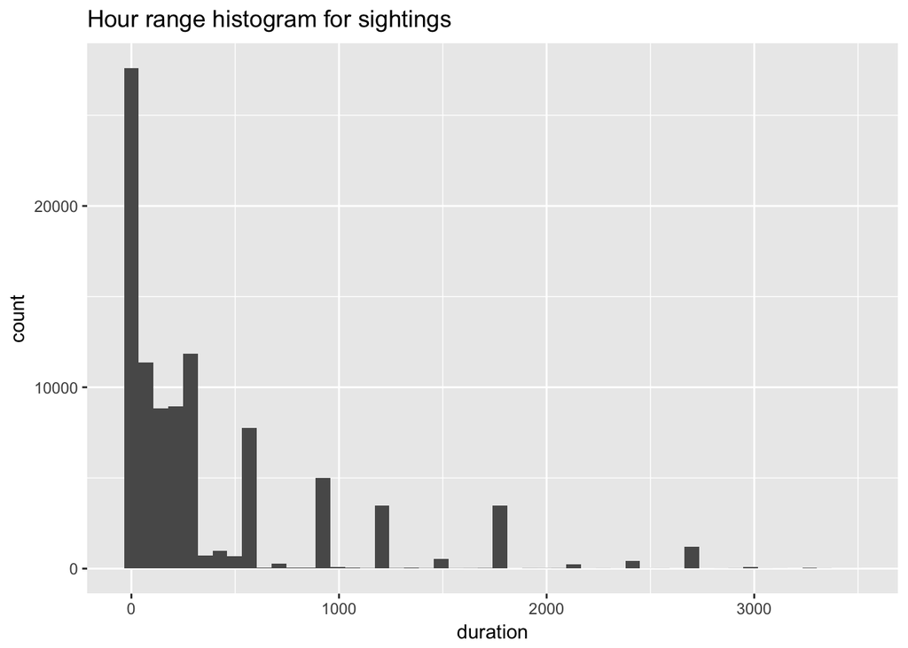

```r
duration_df <- data_frame(duration)
duration_df_lo <- duration_df %>%
  filter(duration < 3600)
ggplot(duration_df_lo, aes(x = duration)) + geom_histogram(bins = 50) + ggtitle("Hour range histogram for sightings")
```

```r
#percentage of duration for low values
lo_size <- dim(duration_df_lo)[1]
total_size <- dim(duration_df)[1]
print(sprintf("Perc. Sightings that are under 1 hour: %f", lo_size / total_size))
```

```
## [1] "Perc. Sightings that are under 1 hour: 0.930896"
```

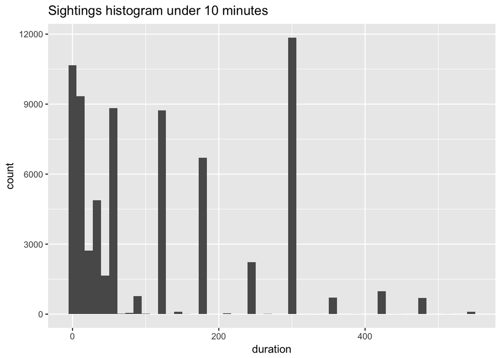

```r
duration_df_lo <- duration_df %>%
  filter(duration < 600)
ggplot(duration_df_lo, aes(x = duration)) + geom_histogram(bins = 50) + ggtitle("Sightings histogram under 10 minutes")
```

```r
#percentage of duration for low values
lo_size <- dim(duration_df_lo)[1]
total_size <- dim(duration_df)[1]
print(sprintf("Perc. Sightings that are under 10 minutes: %f", lo_size / total_size))
```

```
## [1] "Perc. Sightings that are under 10 minutes: 0.703814"
```

Included in the dataset was the `summary` column that included whether the sighting was considered a hoax. the site has this to say: “We encourage visitors to our site to always be on the alert for errors and hoaxed reports, and in particular, with regard to those reports that have been submitted by parties who elect to remain anonymous. We have attempted to label those reports that have been submitted by individuals who do not share their names or contact information together with their reports.(http://www.nuforc.org/)”

We included a column to be able to differentiate between hoaxes.

```r
ishoax <- function(comment){

  if(length(comment) == 0){
    return(FALSE)
  }
  else{
  splitted_com <- strsplit(comment, " ")
  for(i in unlist(splitted_com)){
    if(grepl("HOAX", i) | grepl("hoax", i) | grepl("Hoax", i) ){
      return(TRUE)
    }
  }

  return(FALSE)
  }
}

ufo <- ufo %>% mutate(`Hoax` = lapply(ufo$Summary, ishoax))
ufo$Hoax <- unlist(ufo$Hoax)
```

Since the `Shape` column had so many different kinds included, we consolidated them. We had different opinions on what bins would work well for analysis, so we included multiple versions.

```r
bin_shape1 <- function(shape){
  if(shape %in% c("hexagon", "rectangle", "diamond", "cross")){
    return("Rectangle")
  }
  else if(shape %in% c("chevron", "delta", "pyramid", "triangle")){
    return("Triangle")
  }
  else if(shape %in% c("cigar","circle","cylinder","cone","crescent","disk","dome","egg","oval","round", "sphere", "teardrop")){
    return("Circle")
  }
  else if(shape %in% c("fireball", "flare", "flash", "light")){
    return("Light")
  }
  else if(shape %in% c(NA)) {
    return(NA)
  }
  return(shape)

}

bin_shape2 <- function(shape){
  if(shape %in% c("hexagon", "rectangle", "diamond", "cross")){
    return("Rectangle")
  }
  else if(shape %in% c("chevron", "delta", "pyramid", "triangle")){
    return("Triangle")
  }
  else if(shape %in% c("cigar","circle","cylinder","cone","crescent","disk","dome","egg","oval","round", "sphere", "teardrop")){
    return("Circle")
  }
  else if(shape %in% c("fireball", "flare", "flash", "light")){
    return("Light")
  }
  else if(shape %in% c(NA)) {
    return(NA)
  }
  return("Other")

}

bin_shape3 <- function(shape){
  if(shape %in% c("hexagon", "rectangle", "diamond")){
    return("Rectangle")
  }
  else if(shape %in% c("chevron", "delta", "pyramid", "triangle")){
    return("Triangle")
  }
  else if(shape %in% c("circle","cone","crescent","dome","egg","round")){
    return("Circle")
  }
  else if(shape %in% c("fireball", "flare", "flash", "light")){
    return("Light")
  }
  else if(shape %in% c(NA)) {
    return(NA)
  }
  return(shape)

}


ufo <- ufo %>% mutate(`Shape1` = lapply(ufo$Shape, bin_shape1))
ufo <- ufo %>% mutate(`Shape2` = lapply(ufo$Shape, bin_shape2))
ufo <- ufo %>% mutate(`Shape3` = lapply(ufo$Shape, bin_shape3))

ufo$Shape1 <- unlist(ufo$Shape1)
ufo$Shape2 <- unlist(ufo$Shape2)
ufo$Shape3 <- unlist(ufo$Shape3)

table(ufo$Shape)
```

```
##
##  changing   chevron     cigar    circle      cone  crescent     cross
##      2781      1334      2747     11833       480         2       351
##  cylinder     delta   diamond      disk      dome       egg  fireball
##      1769         8      1707      7108         1      1023      8798
##     flare     flash formation   hexagon     light     other      oval
##         1      2051      3571         1     23342      7924      5149
##   pyramid rectangle     round    sphere  teardrop  triangle
##         1      1904         2      7573      1041     10719
```

We also got the description length to use for size of sighting report.

```r
#Add Description Length
countWords <- function(entry){
  numWords <- lengths(gregexpr("\\W+", entry)) + 1
  return(numWords)
}


ufo <- ufo %>%
  rowwise() %>%
  mutate(
    DescriptionLength = countWords(Desc),
  )

print(head(ufo, n=5))
```

```
## # A tibble: 5 x 20
##      X1 `Date / Time`                City State    Shape Duration
##   <int>         <chr>               <chr> <chr>    <chr>    <dbl>
## 1     0 6/30/00 00:00 Myers Spring Canyon    TX   circle       NA
## 2     0 3/29/17 05:30             Madison    CT   circle      600
## 3     0 2/15/14 23:30        St. Norbert     MB    light      300
## 4     0 4/14/61 08:00           Nurnburg   <NA> cylinder     1800
## 5     0       7/18/15             London   <NA>     <NA>      600
## # ... with 14 more variables: Summary <chr>, Posted <date>, year <int>,
## #   month <chr>, Desc <chr>, Date <date>, Time <chr>, In_USA <lgl>,
## #   Country <chr>, Hoax <lgl>, Shape1 <chr>, Shape2 <chr>, Shape3 <chr>,
## #   DescriptionLength <dbl>
```

Finally, we write the results to an new CSV and use that file in our analysis.

```r
sapply(ufo, class)
```

```
##                X1       Date / Time              City             State
##         "integer"       "character"       "character"       "character"
##             Shape          Duration           Summary            Posted
##       "character"         "numeric"       "character"            "Date"
##              year             month              Desc              Date
##         "integer"       "character"       "character"            "Date"
##              Time            In_USA           Country              Hoax
##       "character"         "logical"       "character"         "logical"
##            Shape1            Shape2            Shape3 DescriptionLength
##       "character"       "character"       "character"         "numeric"
```

```r
write.csv(ufo, file = "data/ufo_clean_final.csv")
```

```r
ufo_clean <- as_tibble(read_csv("data/ufo_clean_final.csv"))
summary(ufo_clean)
```

```
##        X1              X1_1        Date / Time            City
##  Min.   :     1   Min.   :   0.0   Length:114838      Length:114838
##  1st Qu.: 28710   1st Qu.:  69.0   Class :character   Class :character
##  Median : 57420   Median : 182.0   Mode  :character   Mode  :character
##  Mean   : 57420   Mean   : 222.3
##  3rd Qu.: 86129   3rd Qu.: 325.0
##  Max.   :114838   Max.   :1103.0
##
##     State              Shape              Duration
##  Length:114838      Length:114838      Min.   :0.000e+00
##  Class :character   Class :character   1st Qu.:3.000e+01
##  Mode  :character   Mode  :character   Median :1.800e+02
##                                        Mean   :6.452e+04
##                                        3rd Qu.:6.000e+02
##                                        Max.   :1.388e+09
##                                        NA's   :13971
##    Summary              Posted                year         month
##  Length:114838      Min.   :1998-03-07   Min.   :1400   Length:114838
##  Class :character   1st Qu.:2004-11-02   1st Qu.:2002   Class :character
##  Mode  :character   Median :2009-12-12   Median :2009   Mode  :character
##                     Mean   :2009-06-07   Mean   :2006
##                     3rd Qu.:2014-01-10   3rd Qu.:2013
##                     Max.   :2018-04-05   Max.   :2018
##
##      Desc                Date                Time            In_USA
##  Length:114838      Min.   :1400-06-30   Length:114838     Mode :logical
##  Class :character   1st Qu.:2002-11-30   Class1:hms        FALSE:13268
##  Mode  :character   Median :2009-02-08   Class2:difftime   TRUE :101570
##                     Mean   :2006-06-29   Mode  :numeric
##                     3rd Qu.:2013-10-19
##                     Max.   :2018-04-05
##
##    Country             Hoax            Shape1             Shape2
##  Length:114838      Mode :logical   Length:114838      Length:114838
##  Class :character   FALSE:113534    Class :character   Class :character
##  Mode  :character   TRUE :1304      Mode  :character   Mode  :character
##
##
##
##
##     Shape3          DescriptionLength
##  Length:114838      Min.   :    2.0
##  Class :character   1st Qu.:   86.0
##  Mode  :character   Median :  149.0
##                     Mean   :  199.5
##                     3rd Qu.:  246.0
##                     Max.   :11687.0
##
```

At this point, we have a clean dataset and are ready to proceed with analysis. EDA material can be found in `part4_eda` files.